# wrftools

Sergio Ibarra-Espinosa

October 29, 2019

## wrftools

This package does 3 things

1. help you to define domains
2. extract data as points of spatial features and bricks
3. returns st_bbox from wrf files

I’m not an expert in WRF but i need to use it. One of the very frustating and tricky part was to make a correct namelist.wps. Hours and hours trying to get the perfect domains. This functions solves this part while providing a dynamic maps for actually viewing where are your domains.

## Install

```r
remotes::install_github("atmoschem/wrftools")
```

## wrf_domains (bug for mid latitudes, good for low latitude regions)

wrf_domains returns a list of:

1. the map
2. the sf object

The arguments of wrf_domains are the same arguments of namelist.wps. It include default values but you can change them accordingly.

```r
library(wrftools)
a <- wrf_domains()
```

```
## Simple feature collection with 3 features and 1 field
## geometry type:  POLYGON
## dimension:      XY
## bbox:           xmin: -58.47369 ymin: -33.3816 xmax: -33.82031 ymax: -9.216399
## epsg (SRID):    4326
## proj4string:    +proj=longlat +datum=WGS84 +no_defs
##   d                       geometry
## 1 1 POLYGON ((-58.47369 -33.381...
## 2 2 POLYGON ((-48.46588 -25.814...
## 3 3 POLYGON ((-47.24542 -24.594...
```

```r
a[[1]] # leaflet
```

[interactive chart not shown]

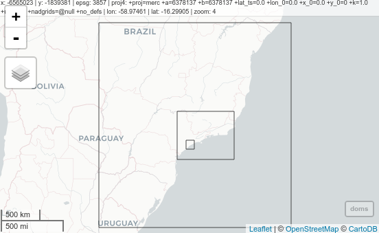

## xtractor

(inspired in NCL from DCA/IAG/USP)

Which returns data.frame ready for ggplot2. The class of Time is POSIXct

- NOW SUPPORTS MANY POINTS*

```r
data(cetesb)
#use your wrfout
wrf <- "wrfoA.nc"
t2 = c("T2", "o3", "no", "no2", "PM10", "PM2_5_DRY")
df <- xtractor(atmos = wrf, vars = t2, points = cetesb,
stations = cetesb$Station)
```

[figure not shown]

and raster bricks

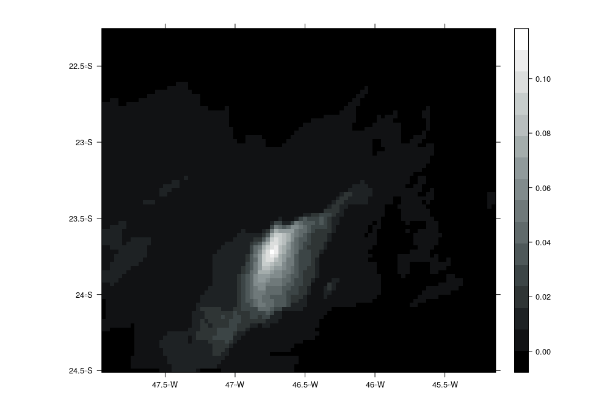

```r
library(cptcity)
r <- xtractor(atmos = wrf, vars = t2, points = cetesb[1, ], return_list = T)
#  A list with raster and data.frame
sp::spplot(r[[1]][[2]], "layer.60",
           scales = list(draw = T), col.regions = cpt(1224))
```

## Contributing

If you see any errors and know how to improve the function, or add new functions write an issue and a pull request, please. I will be ver grateful, for sure, 100%.